# Section A: DATA COLLECTION

## Data Cleaning Checkup before Analysis

```python
NCDC.head()
```

|  | States Affected | No of cases lab | No of Cases | No Discharged | No of Deaths |
| --- | --- | --- | --- | --- | --- |
| 0 | Lagos | 100641 | 1,810 | 98062 | 769 |
| 1 | FCT | 28763 | 63 | 28451 | 249 |
| 2 | Rivers | 16826 | 127 | 16545 | 154 |
| 3 | Kaduna | 11314 | 7 | 11218 | 89 |
| 4 | Plateau | 10258 | 2 | 10181 | 75 |

```python
CovidNig.head()
```

|  | States Affected | No. of Cases (Lab Confirmed) | No. of Cases (on admission) | No. Discharged | No. of Deaths |
| --- | --- | --- | --- | --- | --- |
| 0 | Lagos | 26,708 | 2,435 | 24,037 | 236 |
| 1 | FCT | 9,627 | 2,840 | 6,694 | 93 |
| 2 | Kaduna | 4,504 | 579 | 3,877 | 48 |
| 3 | Plateau | 4,262 | 280 | 3,948 | 34 |
| 4 | Oyo | 3,788 | 368 | 3,374 | 46 |

```python
#Cleaning DataFrame 'CovidNig': Removing Commas
CovidNig['No. of Cases (Lab Confirmed)'] = CovidNig['No. of Cases (Lab Confirmed)'].str.replace(',', '').astype(int)
```

```python
CovidNig['No. of Cases (on admission)'] = CovidNig['No. of Cases (on admission)'].str.replace(',', '').astype(int)
```

```python
CovidNig['No. Discharged'] = CovidNig['No. Discharged'].str.replace(',', '').astype(int)
```

```python
CovidNig.head()
```

|  | States Affected | No. of Cases (Lab Confirmed) | No. of Cases (on admission) | No. Discharged | No. of Deaths |
| --- | --- | --- | --- | --- | --- |
| 0 | Lagos | 26708 | 2435 | 24037 | 236 |
| 1 | FCT | 9627 | 2840 | 6694 | 93 |
| 2 | Kaduna | 4504 | 579 | 3877 | 48 |
| 3 | Plateau | 4262 | 280 | 3948 | 34 |
| 4 | Oyo | 3788 | 368 | 3374 | 46 |

# SECTION C: ANALYSIS

```python
#Generate a plot that shows the Top 10 states in terms of Confirmed Covid cases by Laboratory test
```

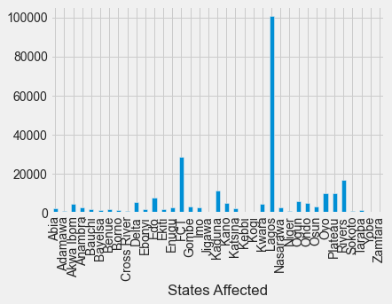

```python
NCDC.groupby(['States Affected'])['No of cases lab'].mean().plot.bar()
```

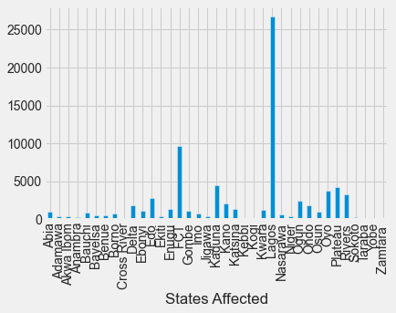

```python
CovidNig.groupby(['States Affected'])['No. of Cases (Lab Confirmed)'].mean().plot.bar()
```

```python
NCDC.head(20)
```

|  | States Affected | No of cases lab | No of Cases | No Discharged | No of Deaths |
| --- | --- | --- | --- | --- | --- |
| 0 | Lagos | 100641 | 1,810 | 98062 | 769 |
| 1 | FCT | 28763 | 63 | 28451 | 249 |
| 2 | Rivers | 16826 | 127 | 16545 | 154 |
| 3 | Kaduna | 11314 | 7 | 11218 | 89 |
| 4 | Plateau | 10258 | 2 | 10181 | 75 |
| 5 | Oyo | 10232 | 1 | 10029 | 202 |
| 6 | Edo | 7707 | 11 | 7375 | 321 |
| 7 | Ogun | 5810 | 11 | 5717 | 82 |
| 8 | Delta | 5413 | 132 | 5170 | 111 |
| 9 | Ondo | 5173 | 315 | 4749 | 109 |
| 10 | Kano | 5087 | 49 | 4911 | 127 |
| 11 | Akwa Ibom | 4659 | 29 | 4586 | 44 |
| 12 | Kwara | 4640 | 401 | 4175 | 64 |
| 13 | Osun | 3311 | 36 | 3183 | 92 |
| 14 | Gombe | 3307 | 83 | 3158 | 66 |
| 15 | Enugu | 2952 | 13 | 2910 | 29 |
| 16 | Anambra | 2825 | 46 | 2760 | 19 |
| 17 | Nasarawa | 2738 | 354 | 2345 | 39 |
| 18 | Imo | 2648 | 8 | 2582 | 58 |
| 19 | Katsina | 2418 | 0 | 2381 | 37 |

```python
NCDCPlot= NCDC[0:11]
```

```python
NCDCPlot
```

|  | States Affected | No of cases lab | No of Cases | No Discharged | No of Deaths |
| --- | --- | --- | --- | --- | --- |
| 0 | Lagos | 100641 | 1,810 | 98062 | 769 |
| 1 | FCT | 28763 | 63 | 28451 | 249 |
| 2 | Rivers | 16826 | 127 | 16545 | 154 |
| 3 | Kaduna | 11314 | 7 | 11218 | 89 |
| 4 | Plateau | 10258 | 2 | 10181 | 75 |
| 5 | Oyo | 10232 | 1 | 10029 | 202 |
| 6 | Edo | 7707 | 11 | 7375 | 321 |
| 7 | Ogun | 5810 | 11 | 5717 | 82 |
| 8 | Delta | 5413 | 132 | 5170 | 111 |
| 9 | Ondo | 5173 | 315 | 4749 | 109 |
| 10 | Kano | 5087 | 49 | 4911 | 127 |

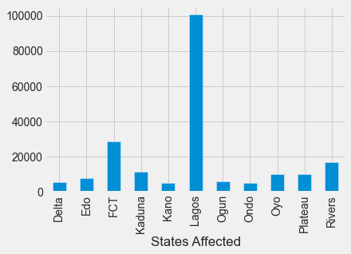

```python
NCDCPlot.groupby(['States Affected'])['No of cases lab'].mean().plot.bar()
```

```python
CovidNig.head(20)
```

|  | States Affected | No. of Cases (Lab Confirmed) | No. of Cases (on admission) | No. Discharged | No. of Deaths |
| --- | --- | --- | --- | --- | --- |
| 0 | Lagos | 26708 | 2435 | 24037 | 236 |
| 1 | FCT | 9627 | 2840 | 6694 | 93 |
| 2 | Kaduna | 4504 | 579 | 3877 | 48 |
| 3 | Plateau | 4262 | 280 | 3948 | 34 |
| 4 | Oyo | 3788 | 368 | 3374 | 46 |
| 5 | Rivers | 3279 | 232 | 2987 | 60 |
| 6 | Edo | 2768 | 52 | 2603 | 113 |
| 7 | Ogun | 2382 | 174 | 2175 | 33 |
| 8 | Kano | 2032 | 198 | 1778 | 56 |
| 9 | Delta | 1843 | 57 | 1737 | 49 |
| 10 | Ondo | 1793 | 62 | 1690 | 41 |
| 11 | Katsina | 1405 | 214 | 1167 | 24 |
| 12 | Enugu | 1376 | 34 | 1321 | 21 |
| 13 | Kwara | 1296 | 171 | 1094 | 31 |
| 14 | Gombe | 1164 | 183 | 950 | 31 |
| 15 | Ebonyi | 1091 | 24 | 1037 | 30 |
| 16 | Abia | 980 | 25 | 945 | 10 |
| 17 | Osun | 979 | 20 | 937 | 22 |
| 18 | Bauchi | 897 | 108 | 775 | 14 |
| 19 | Borno | 778 | 37 | 705 | 36 |

```python
CovidPlot= CovidNig[0:11]
```

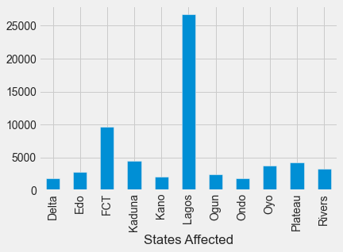

```python
CovidPlot.groupby(['States Affected'])['No. of Cases (Lab Confirmed)'].mean().plot.bar()
```

## Summary of the first 4 plots

Using this two dataframe will give room for comparison and drawing of inferences.

### Inference

-It can be said that the Top 2 states in both dataFrames are Lagos and FCT. With Lagos ranking first in both dataframes. -Rank of states like Rivers, Kaduna and Plateau weren't constant; which will put one a state of which data source is the most accurate. -The bottom region in both data sources showed that Ogun, Kano and Delta evening though the position of Kano and Delta interchanged in NCDC and CovidNig data sources.

```python
#Generate a plot that shows the Top 10 states in terms of Discharged Covid cases.
```

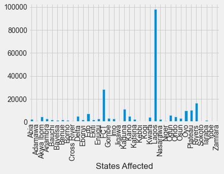

```python
NCDC.groupby(['States Affected'])['No Discharged'].mean().plot.bar()
```

```python
NCDCsorted = NCDC.sort_values("No Discharged", ascending=False)
```

```python
NCDCsorted.head(20)
```

|  | States Affected | No of cases lab | No of Cases | No Discharged | No of Deaths |
| --- | --- | --- | --- | --- | --- |
| 0 | Lagos | 100641 | 1,810 | 98062 | 769 |
| 1 | FCT | 28763 | 63 | 28451 | 249 |
| 2 | Rivers | 16826 | 127 | 16545 | 154 |
| 3 | Kaduna | 11314 | 7 | 11218 | 89 |
| 4 | Plateau | 10258 | 2 | 10181 | 75 |
| 5 | Oyo | 10232 | 1 | 10029 | 202 |
| 6 | Edo | 7707 | 11 | 7375 | 321 |
| 7 | Ogun | 5810 | 11 | 5717 | 82 |
| 8 | Delta | 5413 | 132 | 5170 | 111 |
| 10 | Kano | 5087 | 49 | 4911 | 127 |
| 9 | Ondo | 5173 | 315 | 4749 | 109 |
| 11 | Akwa Ibom | 4659 | 29 | 4586 | 44 |
| 12 | Kwara | 4640 | 401 | 4175 | 64 |
| 13 | Osun | 3311 | 36 | 3183 | 92 |
| 14 | Gombe | 3307 | 83 | 3158 | 66 |
| 15 | Enugu | 2952 | 13 | 2910 | 29 |
| 16 | Anambra | 2825 | 46 | 2760 | 19 |
| 18 | Imo | 2648 | 8 | 2582 | 58 |
| 19 | Katsina | 2418 | 0 | 2381 | 37 |
| 17 | Nasarawa | 2738 | 354 | 2345 | 39 |

```python
NCDCsorted= NCDCsorted[0:10]
```

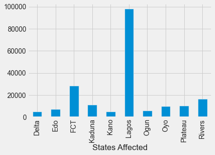

```python
NCDCsorted.groupby(['States Affected'])['No Discharged'].mean().plot.bar()
```

```python
CovidNigsorted = CovidNig.sort_values("No. Discharged", ascending=False)
```

```python
CovidNigsorted.head(20)
```

|  | States Affected | No. of Cases (Lab Confirmed) | No. of Cases (on admission) | No. Discharged | No. of Deaths |
| --- | --- | --- | --- | --- | --- |
| 0 | Lagos | 26708 | 2435 | 24037 | 236 |
| 1 | FCT | 9627 | 2840 | 6694 | 93 |
| 3 | Plateau | 4262 | 280 | 3948 | 34 |
| 2 | Kaduna | 4504 | 579 | 3877 | 48 |
| 4 | Oyo | 3788 | 368 | 3374 | 46 |
| 5 | Rivers | 3279 | 232 | 2987 | 60 |
| 6 | Edo | 2768 | 52 | 2603 | 113 |
| 7 | Ogun | 2382 | 174 | 2175 | 33 |
| 8 | Kano | 2032 | 198 | 1778 | 56 |
| 9 | Delta | 1843 | 57 | 1737 | 49 |
| 10 | Ondo | 1793 | 62 | 1690 | 41 |
| 12 | Enugu | 1376 | 34 | 1321 | 21 |
| 11 | Katsina | 1405 | 214 | 1167 | 24 |
| 13 | Kwara | 1296 | 171 | 1094 | 31 |
| 15 | Ebonyi | 1091 | 24 | 1037 | 30 |
| 14 | Gombe | 1164 | 183 | 950 | 31 |
| 16 | Abia | 980 | 25 | 945 | 10 |
| 17 | Osun | 979 | 20 | 937 | 22 |
| 18 | Bauchi | 897 | 108 | 775 | 14 |
| 19 | Borno | 778 | 37 | 705 | 36 |

```python
CovidNigSplot = CovidNigsorted[0:10]
```

```python
CovidNigSplot.head(5)
```

|  | States Affected | No. of Cases (Lab Confirmed) | No. of Cases (on admission) | No. Discharged | No. of Deaths |
| --- | --- | --- | --- | --- | --- |
| 0 | Lagos | 26708 | 2435 | 24037 | 236 |
| 1 | FCT | 9627 | 2840 | 6694 | 93 |
| 3 | Plateau | 4262 | 280 | 3948 | 34 |
| 2 | Kaduna | 4504 | 579 | 3877 | 48 |
| 4 | Oyo | 3788 | 368 | 3374 | 46 |

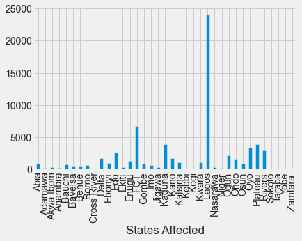

```python
CovidNigsorted.groupby(['States Affected'])['No. Discharged'].mean().plot.bar()
```

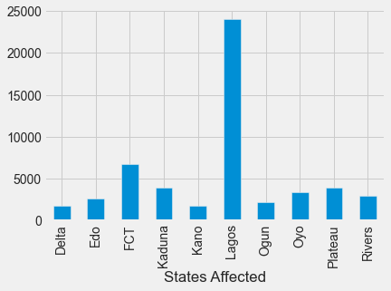

```python
CovidNigSplot.groupby(['States Affected'])['No. Discharged'].mean().plot.bar()
```

## Summary of the first 4 plots on Top 10 Discharged Cases

```
1. NCDC which is the dataframe scrapped from the NCDC website and
2. CovidNig which is the dataframe from the external dataframe.
```

Using this two dataframe will give room for comparison and drawing of inferences.

## Details of Plots

Plot3 and 4= these bar charts are just to show the Top10 states more explicitly.

## Inference

-It can be said that the Top 2 states in both dataFrames are Lagos and FCT. With Lagos ranking first in both dataframes. Which means Lagos and FCT has highest discharged. -Discharged rate of states like Rivers, Kaduna and Plateau weren't constant in the two differnt dataframes. which will put one a state of which data source is the most accurate. -The bottom region in both data sources showed that Ogun, Kano and Delta evening though the position of Kano and Delta interchanged in NCDC and CovidNig data sources.

```python
#Plotting the top 10 Death cases
```

```python
#First arranging NCDC and CovidNig Death records in descending order
```

```python
NCDCdeaths = NCDC.sort_values("No of Deaths", ascending=False)
```

```python
NCDCdeaths.head(15)
```

|  | States Affected | No of cases lab | No of Cases | No Discharged | No of Deaths |
| --- | --- | --- | --- | --- | --- |
| 0 | Lagos | 100641 | 1,810 | 98062 | 769 |
| 6 | Edo | 7707 | 11 | 7375 | 321 |
| 1 | FCT | 28763 | 63 | 28451 | 249 |
| 5 | Oyo | 10232 | 1 | 10029 | 202 |
| 2 | Rivers | 16826 | 127 | 16545 | 154 |
| 10 | Kano | 5087 | 49 | 4911 | 127 |
| 8 | Delta | 5413 | 132 | 5170 | 111 |
| 9 | Ondo | 5173 | 315 | 4749 | 109 |
| 13 | Osun | 3311 | 36 | 3183 | 92 |
| 3 | Kaduna | 11314 | 7 | 11218 | 89 |
| 7 | Ogun | 5810 | 11 | 5717 | 82 |
| 4 | Plateau | 10258 | 2 | 10181 | 75 |
| 14 | Gombe | 3307 | 83 | 3158 | 66 |
| 12 | Kwara | 4640 | 401 | 4175 | 64 |
| 18 | Imo | 2648 | 8 | 2582 | 58 |

```python
CovidNigdeaths = CovidNig.sort_values("No. of Deaths", ascending=False)
```

```python
CovidNigdeaths.head(15)
```

|  | States Affected | No. of Cases (Lab Confirmed) | No. of Cases (on admission) | No. Discharged | No. of Deaths |
| --- | --- | --- | --- | --- | --- |
| 0 | Lagos | 26708 | 2435 | 24037 | 236 |
| 6 | Edo | 2768 | 52 | 2603 | 113 |
| 1 | FCT | 9627 | 2840 | 6694 | 93 |
| 5 | Rivers | 3279 | 232 | 2987 | 60 |
| 8 | Kano | 2032 | 198 | 1778 | 56 |
| 9 | Delta | 1843 | 57 | 1737 | 49 |
| 2 | Kaduna | 4504 | 579 | 3877 | 48 |
| 4 | Oyo | 3788 | 368 | 3374 | 46 |
| 10 | Ondo | 1793 | 62 | 1690 | 41 |
| 19 | Borno | 778 | 37 | 705 | 36 |
| 3 | Plateau | 4262 | 280 | 3948 | 34 |
| 7 | Ogun | 2382 | 174 | 2175 | 33 |
| 13 | Kwara | 1296 | 171 | 1094 | 31 |
| 14 | Gombe | 1164 | 183 | 950 | 31 |
| 15 | Ebonyi | 1091 | 24 | 1037 | 30 |

```python
#Sorting out the Top 10 states with Death cases from both DataFrame
```

```python
NCDCdea_sorted= NCDCdeaths[0:10]
```

```python
NCDCdea_sorted
```

|  | States Affected | No of cases lab | No of Cases | No Discharged | No of Deaths |
| --- | --- | --- | --- | --- | --- |
| 0 | Lagos | 100641 | 1,810 | 98062 | 769 |
| 6 | Edo | 7707 | 11 | 7375 | 321 |
| 1 | FCT | 28763 | 63 | 28451 | 249 |
| 5 | Oyo | 10232 | 1 | 10029 | 202 |
| 2 | Rivers | 16826 | 127 | 16545 | 154 |
| 10 | Kano | 5087 | 49 | 4911 | 127 |
| 8 | Delta | 5413 | 132 | 5170 | 111 |
| 9 | Ondo | 5173 | 315 | 4749 | 109 |
| 13 | Osun | 3311 | 36 | 3183 | 92 |
| 3 | Kaduna | 11314 | 7 | 11218 | 89 |

```python
Covid_dea_sorted= CovidNigdeaths[0:10]
```

```python
Covid_dea_sorted
```

|  | States Affected | No. of Cases (Lab Confirmed) | No. of Cases (on admission) | No. Discharged | No. of Deaths |
| --- | --- | --- | --- | --- | --- |
| 0 | Lagos | 26708 | 2435 | 24037 | 236 |
| 6 | Edo | 2768 | 52 | 2603 | 113 |
| 1 | FCT | 9627 | 2840 | 6694 | 93 |
| 5 | Rivers | 3279 | 232 | 2987 | 60 |
| 8 | Kano | 2032 | 198 | 1778 | 56 |
| 9 | Delta | 1843 | 57 | 1737 | 49 |
| 2 | Kaduna | 4504 | 579 | 3877 | 48 |
| 4 | Oyo | 3788 | 368 | 3374 | 46 |
| 10 | Ondo | 1793 | 62 | 1690 | 41 |
| 19 | Borno | 778 | 37 | 705 | 36 |

```python
#Ploting the Graphs of Top 10 states via the two dataframes
```

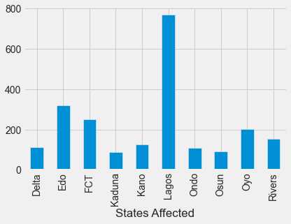

```python
NCDCdea_sorted.groupby(['States Affected'])['No of Deaths'].mean().plot.bar()
```

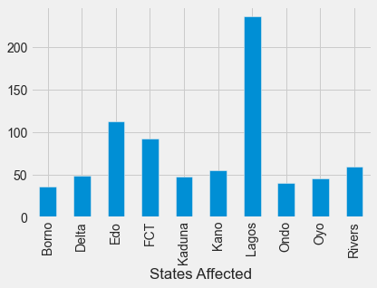

```python
Covid_dea_sorted.groupby(['States Affected'])['No. of Deaths'].mean().plot.bar()
```

### Summary of the 2 plots on Top 10 Death Cases

Using this two dataframe will give room for comparison and drawing of inferences.

### Details of Plots

Plot1 and 2= the graph is a bar chart showing the mean value of the Number of death Case in each states using NCDC and CovidNig. The top 10 states with high Death casualities in NCDC are: Lagos, Edo, FCT, Oyo, Rivers, Kano, Delta, Ondo, Osun and Kaduna. and CovidNig are: Lagos, Edo, FCT, Rivers, Kano, Delta, Kaduna, Oyo, Ondo and Borno respectively.

### Inference

- It can be said that most of the states with high lab confirmation cases has high death casualities.
- Also, the data on the CovidNig wasn't consistent with the NCDC data. As Borno state is part of the top 10 states with death casuality on the CovidNig dataframe

```python
#Generating a line plot for the total daily confirmed, recovered and death cases in Nigeria
```

```python
#Ploting using CoNig, ReNig and DeNig as the total daily confirmed, recovered and death cases in Nigeria
```

```python
CoNig.tail(10)
```

|  | Date | Cases |
| --- | --- | --- |
| 859 | 2022-05-30 | 256028 |
| 860 | 2022-05-31 | 256028 |
| 861 | 2022-06-01 | 256028 |
| 862 | 2022-06-02 | 256113 |
| 863 | 2022-06-03 | 256113 |
| 864 | 2022-06-04 | 256148 |
| 865 | 2022-06-05 | 256148 |
| 866 | 2022-06-06 | 256148 |
| 867 | 2022-06-07 | 256227 |
| 868 | 2022-06-08 | 256227 |

```python
import seaborn as sbn
```

```python
import matplotlib.pyplot as plt
```

[figure not shown]

```python
sns.catplot(x='Cases', y='Date', aspect= 8, kind= 'point', data = CoNig)
```

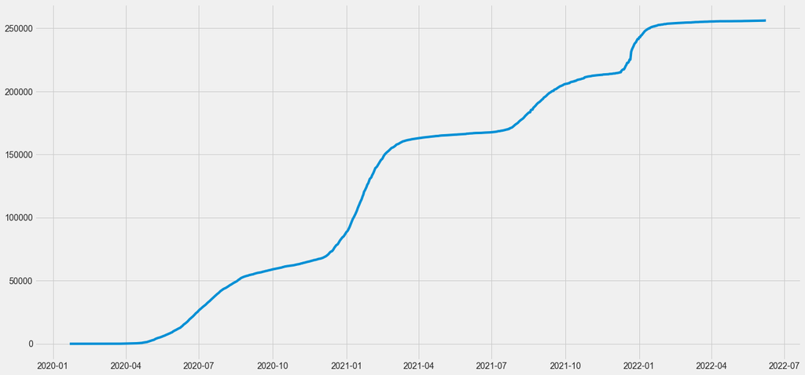

```python
fig = plt.figure(figsize=(20,10))
ax = fig.add_subplot()
ax.plot(CoNig.Date, CoNig.Cases)
```

```python
#Plotting graph of Total daily Recovery using ReNig Dataset
```

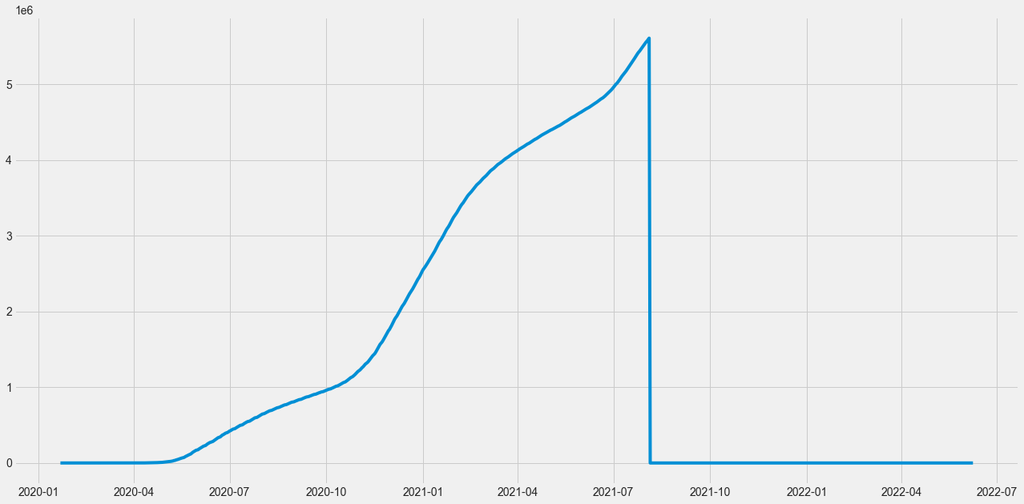

```python
fig = plt.figure(figsize=(20,10))
ax = fig.add_subplot()
ax.plot(ReNig.Date, ReNig.Cases)
```

```python
#Plotting the graphs of total death cases in Nigeria usinf DeNig Dataset
```

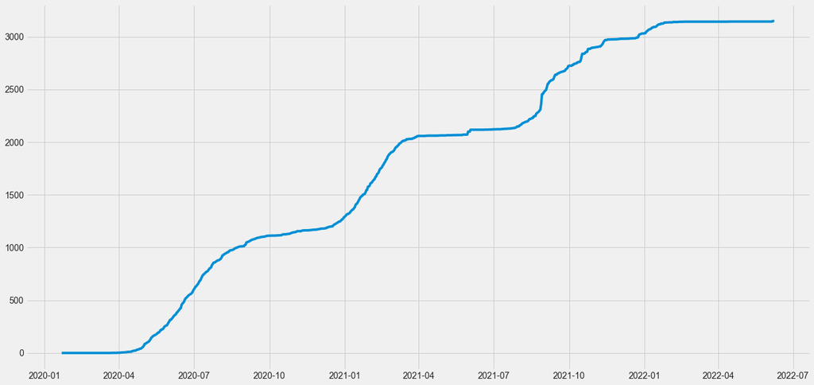

```python
fig = plt.figure(figsize=(20,10))
ax = fig.add_subplot()
ax.plot(DeNig.Date, DeNig.Cases)
```

#### Plot 1: A line graph of total confirmed Cases

This graphs shows that is a daily increase in the total confirm cases. It can also be infered that from April,2022 the number of cases confirmed seemed constant or stead.

#### Plot 3: A line graph of total death Cases

The plot of death cases is quite similar to that of confirmed cases, as there is a consistent increase in the number of recorded death cases in Nigeria as the date goes by.

# Todo F

#### Determine the daily infection rate, you can use the Pandas diff method to find the derivate of the total cases. Then plot the line graph

```python
#Dataset will be use is the confirmed cases (CoNig), where there will be row 1 will be removed from row 2 and so on
```

```python
CoNig.head(5)
```

|  | Date | Cases |
| --- | --- | --- |
| 0 | 2020-01-22 | 0 |
| 1 | 2020-01-23 | 0 |
| 2 | 2020-01-24 | 0 |
| 3 | 2020-01-25 | 0 |
| 4 | 2020-01-26 | 0 |

```python
DIR = CoNig.diff()
```

```python
DIR
```

|  | Date | Cases |
| --- | --- | --- |
| 0 | NaT | NaN |
| 1 | 1 days | 0 |
| 2 | 1 days | 0 |
| 3 | 1 days | 0 |
| 4 | 1 days | 0 |
| ... | ... | ... |
| 864 | 1 days | 35 |
| 865 | 1 days | 0 |
| 866 | 1 days | 0 |
| 867 | 1 days | 79 |
| 868 | 1 days | 0 |

869 rows × 2 columns

```python
#Plotting the Line graphs of the Daily Infection Rate
```

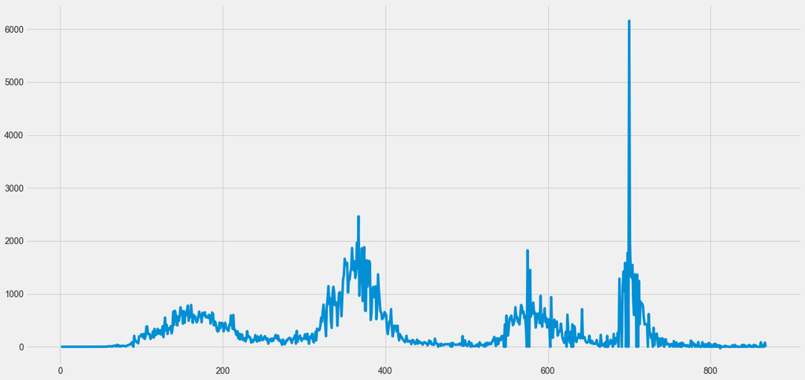

```python
fig = plt.figure(figsize=(20,10))
ax = fig.add_subplot()
ax.plot(DIR.Cases)
```

# TODO G

### Calculate maximum infection rate for a day (Number of new cases)

```python
#Arranging the Daily infection rate in Descending order to find the maximum number of cases of Infection rate
```

```python
DIRsorted = DIR.sort_values("Cases", ascending=False)
```

```python
DIRsorted
```

|  | Date | Cases |
| --- | --- | --- |
| 700 | 1 days | 6158 |
| 367 | 1 days | 2464 |
| 365 | 1 days | 1964 |
| 701 | 1 days | 1940 |
| 374 | 1 days | 1883 |
| ... | ... | ... |
| 577 | 1 days | 0 |
| 603 | 1 days | 0 |
| 868 | 1 days | 0 |
| 812 | 1 days | -30 |
| 0 | NaT | NaN |

869 rows × 2 columns

#### it is shown that the highest number of cases is 6158(new cases) in a day on index number 700.

so what date falls on the index 700?

```python
#Checking the confirm cases dataset CoNig to get the date on index 700
```

```python
CoNig.loc[700]
```

```
Date     2021-12-22 00:00:00
Cases                 231413
Name: 700, dtype: object
```

```python
CoNig.tail(169)
```

|  | Date | Cases |
| --- | --- | --- |
| 700 | 2021-12-22 | 231413 |
| 701 | 2021-12-23 | 233353 |
| 702 | 2021-12-24 | 234709 |
| 703 | 2021-12-25 | 236014 |
| 704 | 2021-12-26 | 237561 |
| ... | ... | ... |
| 864 | 2022-06-04 | 256148 |
| 865 | 2022-06-05 | 256148 |
| 866 | 2022-06-06 | 256148 |
| 867 | 2022-06-07 | 256227 |
| 868 | 2022-06-08 | 256227 |

169 rows × 2 columns

### The date with the highest new cases i.e maximum daily infection rate is 2021-12-22 with 231413 total recorded case of which 6158 infections per day

# TODO H

Determine the relationship between the external dataset and the NCDC COVID-19 dataset. Here you will generate a line plot of top 10 confirmed cases and the overall community vulnerability index on the same axis. From the graph, explain your observation. Steps

```python
#Loading Datasets
```

```python
NCDC.head(5)
```

|  | States Affected | No of cases lab | No of Cases | No Discharged | No of Deaths |
| --- | --- | --- | --- | --- | --- |
| 0 | Lagos | 100641 | 1,810 | 98062 | 769 |
| 1 | FCT | 28763 | 63 | 28451 | 249 |
| 2 | Rivers | 16826 | 127 | 16545 | 154 |
| 3 | Kaduna | 11314 | 7 | 11218 | 89 |
| 4 | Plateau | 10258 | 2 | 10181 | 75 |

```python
CovidOther.head(5)
```

|  | states | region | Population | Overall CCVI Index | Age | Epidemiological | Fragility | Health System | Population Density | Socio-Economic | Transport Availability | Acute IHR |
| --- | --- | --- | --- | --- | --- | --- | --- | --- | --- | --- | --- | --- |
| 0 | FCT | North Central | 4865000 | 0.3 | 0.0 | 0.9 | 0.4 | 0.6 | 0.9 | 0.6 | 0.2 | 0.79 |
| 1 | Plateau | North Central | 4766000 | 0.4 | 0.5 | 0.4 | 0.8 | 0.3 | 0.3 | 0.5 | 0.3 | 0.93 |
| 2 | Kwara | North Central | 3524000 | 0.3 | 0.4 | 0.3 | 0.2 | 0.4 | 0.2 | 0.6 | 0.7 | 0.93 |
| 3 | Nassarawa | North Central | 2783000 | 0.1 | 0.3 | 0.5 | 0.9 | 0.0 | 0.1 | 0.6 | 0.5 | 0.85 |
| 4 | Niger | North Central | 6260000 | 0.6 | 0.0 | 0.6 | 0.3 | 0.7 | 0.1 | 0.8 | 0.8 | 0.84 |

```python
CovidOther.rename(columns = {'states':'States Affected'}, inplace = True)
```

```python
CovidOther.head(5)
```

|  | States Affected | region | Population | Overall CCVI Index | Age | Epidemiological | Fragility | Health System | Population Density | Socio-Economic | Transport Availability | Acute IHR |
| --- | --- | --- | --- | --- | --- | --- | --- | --- | --- | --- | --- | --- |
| 0 | FCT | North Central | 4865000 | 0.3 | 0.0 | 0.9 | 0.4 | 0.6 | 0.9 | 0.6 | 0.2 | 0.79 |
| 1 | Plateau | North Central | 4766000 | 0.4 | 0.5 | 0.4 | 0.8 | 0.3 | 0.3 | 0.5 | 0.3 | 0.93 |
| 2 | Kwara | North Central | 3524000 | 0.3 | 0.4 | 0.3 | 0.2 | 0.4 | 0.2 | 0.6 | 0.7 | 0.93 |
| 3 | Nassarawa | North Central | 2783000 | 0.1 | 0.3 | 0.5 | 0.9 | 0.0 | 0.1 | 0.6 | 0.5 | 0.85 |
| 4 | Niger | North Central | 6260000 | 0.6 | 0.0 | 0.6 | 0.3 | 0.7 | 0.1 | 0.8 | 0.8 | 0.84 |

```python
#Merging the two datasets together on a similar column
```

```python
NCDC_Other = NCDC.merge(CovidOther, how= 'outer')
```

```python
NCDC_Other
```

|  | States Affected | No of cases lab | No of Cases | No Discharged | No of Deaths | region | Population | Overall CCVI Index | Age | Epidemiological | Fragility | Health System | Population Density | Socio-Economic | Transport Availability | Acute IHR |
| --- | --- | --- | --- | --- | --- | --- | --- | --- | --- | --- | --- | --- | --- | --- | --- | --- |
| 0 | Lagos | 100641.0 | 1,810 | 98062.0 | 769.0 | South West | 13992000.0 | 0.0 | 0.1 | 1.0 | 0.3 | 0.1 | 1.0 | 0.1 | 0.4 | 0.93 |
| 1 | FCT | 28763.0 | 63 | 28451.0 | 249.0 | North Central | 4865000.0 | 0.3 | 0.0 | 0.9 | 0.4 | 0.6 | 0.9 | 0.6 | 0.2 | 0.79 |
| 2 | Rivers | 16826.0 | 127 | 16545.0 | 154.0 | South South | 7763000.0 | 0.4 | 0.5 | 0.9 | 0.6 | 0.6 | 0.9 | 0.1 | 0.1 | 1.00 |
| 3 | Kaduna | 11314.0 | 7 | 11218.0 | 89.0 | North West | 9227000.0 | 0.7 | 0.1 | 0.9 | 0.8 | 0.9 | 0.4 | 0.6 | 0.4 | 0.86 |
| 4 | Plateau | 10258.0 | 2 | 10181.0 | 75.0 | North Central | 4766000.0 | 0.4 | 0.5 | 0.4 | 0.8 | 0.3 | 0.3 | 0.5 | 0.3 | 0.93 |
| 5 | Oyo | 10232.0 | 1 | 10029.0 | 202.0 | South West | 8737000.0 | 0.2 | 0.7 | 0.8 | 0.2 | 0.8 | 0.6 | 0.2 | 0.3 | 1.06 |
| 6 | Edo | 7707.0 | 11 | 7375.0 | 321.0 | South South | 4705000.0 | 0.1 | 0.9 | 0.8 | 0.1 | 0.1 | 0.5 | 0.4 | 0.3 | 1.09 |
| 7 | Ogun | 5810.0 | 11 | 5717.0 | 82.0 | South West | 5878000.0 | 0.3 | 0.6 | 0.7 | 0.5 | 0.6 | 0.6 | 0.0 | 0.2 | 1.07 |
| 8 | Delta | 5413.0 | 132 | 5170.0 | 111.0 | South South | 6303000.0 | 0.4 | 0.6 | 0.7 | 0.2 | 1.0 | 0.6 | 0.5 | 0.4 | 1.08 |
| 9 | Ondo | 5173.0 | 315 | 4749.0 | 109.0 | South West | 5185000.0 | 0.1 | 0.8 | 0.5 | 0.1 | 0.3 | 0.6 | 0.3 | 0.3 | 1.04 |
| 10 | Kano | 5087.0 | 49 | 4911.0 | 127.0 | North West | 14726000.0 | 0.6 | 0.2 | 0.1 | 0.3 | 0.4 | 0.8 | 0.8 | 0.5 | 0.87 |
| 11 | Akwa Ibom | 4659.0 | 29 | 4586.0 | 44.0 | South East | 6093000.0 | 0.7 | 0.8 | 0.7 | 0.6 | 0.8 | 0.8 | 0.5 | 0.1 | 1.01 |
| 12 | Kwara | 4640.0 | 401 | 4175.0 | 64.0 | North Central | 3524000.0 | 0.3 | 0.4 | 0.3 | 0.2 | 0.4 | 0.2 | 0.6 | 0.7 | 0.93 |
| 13 | Osun | 3311.0 | 36 | 3183.0 | 92.0 | South West | 5252000.0 | 0.0 | 0.7 | 0.4 | 0.4 | 0.0 | 0.8 | 0.1 | 0.2 | 1.06 |
| 14 | Gombe | 3307.0 | 83 | 3158.0 | 66.0 | North East | 3692000.0 | 1.0 | 0.4 | 0.4 | 0.9 | 0.9 | 0.3 | 0.8 | 0.7 | 0.83 |
| 15 | Enugu | 2952.0 | 13 | 2910.0 | 29.0 | South East | 4801000.0 | 0.2 | 0.9 | 0.4 | 0.0 | 0.3 | 0.7 | 0.4 | 0.1 | 1.14 |
| 16 | Anambra | 2825.0 | 46 | 2760.0 | 19.0 | South East | 6050000.0 | 0.6 | 0.9 | 1.0 | 0.6 | 0.2 | 1.0 | 0.0 | 0.1 | 1.08 |
| 17 | Nasarawa | 2738.0 | 354 | 2345.0 | 39.0 | NaN | NaN | NaN | NaN | NaN | NaN | NaN | NaN | NaN | NaN | NaN |
| 18 | Imo | 2648.0 | 8 | 2582.0 | 58.0 | South East | 6018000.0 | 0.4 | 1.0 | 0.9 | 0.0 | 0.4 | 0.9 | 0.4 | 0.0 | 1.12 |
| 19 | Katsina | 2418.0 | 0 | 2381.0 | 37.0 | North West | 8713000.0 | 0.7 | 0.1 | 0.1 | 0.3 | 0.2 | 0.6 | 0.9 | 0.8 | 0.85 |
| 20 | Abia | 2177.0 | 1 | 2142.0 | 34.0 | South East | 4190000.0 | 0.2 | 0.9 | 0.6 | 0.1 | 0.3 | 0.9 | 0.2 | 0.0 | 1.14 |
| 21 | Benue | 2129.0 | 340 | 1764.0 | 25.0 | North Central | 6376000.0 | 0.5 | 0.7 | 0.5 | 0.7 | 0.4 | 0.4 | 0.3 | 0.5 | 0.91 |
| 22 | Ebonyi | 2064.0 | 28 | 2004.0 | 32.0 | South South | 3192000.0 | 0.6 | 1.0 | 0.0 | 0.6 | 0.1 | 0.7 | 0.3 | 0.6 | 1.00 |
| 23 | Ekiti | 2006.0 | 52 | 1926.0 | 28.0 | South West | 3593000.0 | 0.3 | 0.8 | 0.3 | 0.5 | 0.2 | 0.8 | 0.1 | 0.4 | 1.03 |
| 24 | Bauchi | 1967.0 | 1 | 1942.0 | 24.0 | North East | 7270000.0 | 0.8 | 0.1 | 0.2 | 0.8 | 0.8 | 0.2 | 0.8 | 0.8 | 0.85 |
| 25 | Borno | 1629.0 | 5 | 1580.0 | 44.0 | North East | 6651000.0 | 0.9 | 0.3 | 0.1 | 1.0 | 1.0 | 0.1 | 0.7 | 0.9 | 0.89 |
| 26 | Taraba | 1473.0 | 62 | 1377.0 | 34.0 | North East | 3387000.0 | 0.8 | 0.6 | 0.8 | 0.9 | 0.5 | 0.0 | 0.7 | 0.9 | 0.86 |
| 27 | Bayelsa | 1321.0 | 1 | 1292.0 | 28.0 | South South | 2606000.0 | 0.5 | 0.8 | 0.6 | 0.1 | 0.9 | 0.5 | 0.2 | 0.7 | 1.00 |
| 28 | Adamawa | 1203.0 | 68 | 1103.0 | 32.0 | North East | 4672000.0 | 0.8 | 0.5 | 0.6 | 0.9 | 0.7 | 0.3 | 0.7 | 0.6 | 0.94 |
| 29 | Niger | 1148.0 | 130 | 998.0 | 20.0 | North Central | 6260000.0 | 0.6 | 0.0 | 0.6 | 0.3 | 0.7 | 0.1 | 0.8 | 0.8 | 0.84 |
| 30 | Cross River | 842.0 | 8 | 809.0 | 25.0 | NaN | NaN | NaN | NaN | NaN | NaN | NaN | NaN | NaN | NaN | NaN |
| 31 | Sokoto | 818.0 | 0 | 790.0 | 28.0 | North West | 5612000.0 | 0.9 | 0.3 | 0.2 | 0.4 | 0.7 | 0.3 | 1.0 | 1.0 | 0.89 |
| 32 | Jigawa | 669.0 | 2 | 649.0 | 18.0 | North West | 6435000.0 | 0.9 | 0.4 | 0.0 | 0.7 | 0.6 | 0.5 | 0.9 | 0.8 | 0.92 |
| 33 | Yobe | 609.0 | 0 | 600.0 | 9.0 | North East | 3723000.0 | 1.0 | 0.6 | 0.3 | 1.0 | 0.5 | 0.0 | 0.9 | 1.0 | 0.87 |
| 34 | Kebbi | 480.0 | 10 | 454.0 | 16.0 | North West | 4968000.0 | 0.8 | 0.2 | 0.3 | 0.4 | 0.9 | 0.1 | 0.9 | 0.9 | 0.85 |
| 35 | Zamfara | 375.0 | 0 | 366.0 | 9.0 | North West | 4974000.0 | 0.9 | 0.2 | 0.1 | 0.7 | 0.8 | 0.2 | 1.0 | 0.9 | 0.87 |
| 36 | Kogi | 5.0 | 0 | 3.0 | 2.0 | North Central | 4970000.0 | 0.1 | 0.3 | 0.2 | 0.5 | 0.5 | 0.4 | 0.3 | 0.6 | 0.87 |
| 37 | Nassarawa | NaN | NaN | NaN | NaN | North Central | 2783000.0 | 0.1 | 0.3 | 0.5 | 0.9 | 0.0 | 0.1 | 0.6 | 0.5 | 0.85 |
| 38 | Cross river | NaN | NaN | NaN | NaN | South South | 4272000.0 | 0.5 | 0.4 | 0.7 | 0.8 | 0.1 | 0.4 | 0.4 | 0.6 | 0.98 |

```python
#Create a new dataframe for plotting. This DataFrame will contain top 10 states in terms of confirmed cases i.e sort by confirmed cases.
```

```python
Othertop10 = NCDC_Other.nlargest(10, "No of cases lab")
```

```python
Othertop10
```

|  | States Affected | No of cases lab | No of Cases | No Discharged | No of Deaths | region | Population | Overall CCVI Index | Age | Epidemiological | Fragility | Health System | Population Density | Socio-Economic | Transport Availability | Acute IHR |
| --- | --- | --- | --- | --- | --- | --- | --- | --- | --- | --- | --- | --- | --- | --- | --- | --- |
| 0 | Lagos | 100641.0 | 1,810 | 98062.0 | 769.0 | South West | 13992000.0 | 0.0 | 0.1 | 1.0 | 0.3 | 0.1 | 1.0 | 0.1 | 0.4 | 0.93 |
| 1 | FCT | 28763.0 | 63 | 28451.0 | 249.0 | North Central | 4865000.0 | 0.3 | 0.0 | 0.9 | 0.4 | 0.6 | 0.9 | 0.6 | 0.2 | 0.79 |
| 2 | Rivers | 16826.0 | 127 | 16545.0 | 154.0 | South South | 7763000.0 | 0.4 | 0.5 | 0.9 | 0.6 | 0.6 | 0.9 | 0.1 | 0.1 | 1.00 |
| 3 | Kaduna | 11314.0 | 7 | 11218.0 | 89.0 | North West | 9227000.0 | 0.7 | 0.1 | 0.9 | 0.8 | 0.9 | 0.4 | 0.6 | 0.4 | 0.86 |
| 4 | Plateau | 10258.0 | 2 | 10181.0 | 75.0 | North Central | 4766000.0 | 0.4 | 0.5 | 0.4 | 0.8 | 0.3 | 0.3 | 0.5 | 0.3 | 0.93 |
| 5 | Oyo | 10232.0 | 1 | 10029.0 | 202.0 | South West | 8737000.0 | 0.2 | 0.7 | 0.8 | 0.2 | 0.8 | 0.6 | 0.2 | 0.3 | 1.06 |
| 6 | Edo | 7707.0 | 11 | 7375.0 | 321.0 | South South | 4705000.0 | 0.1 | 0.9 | 0.8 | 0.1 | 0.1 | 0.5 | 0.4 | 0.3 | 1.09 |
| 7 | Ogun | 5810.0 | 11 | 5717.0 | 82.0 | South West | 5878000.0 | 0.3 | 0.6 | 0.7 | 0.5 | 0.6 | 0.6 | 0.0 | 0.2 | 1.07 |
| 8 | Delta | 5413.0 | 132 | 5170.0 | 111.0 | South South | 6303000.0 | 0.4 | 0.6 | 0.7 | 0.2 | 1.0 | 0.6 | 0.5 | 0.4 | 1.08 |
| 9 | Ondo | 5173.0 | 315 | 4749.0 | 109.0 | South West | 5185000.0 | 0.1 | 0.8 | 0.5 | 0.1 | 0.3 | 0.6 | 0.3 | 0.3 | 1.04 |

```python
#Plotting the graphs
```

```python
Othertop10.rename(columns = {'States Affected':'States'}, inplace = True)
```

```python
Othertop10.States
```

```
0      Lagos
1        FCT
2     Rivers
3     Kaduna
4    Plateau
5        Oyo
6        Edo
7       Ogun
8      Delta
9       Ondo
Name: States, dtype: object
```

```python
fig = plt.figure(figsize=(20,10))
ax1 = fig.add_subplot()
ax1.plot(Othertop10.States, Other_top10.No of cases lab)
ax1.set_ylabel('Confirmed Cases')

ax2 = ax1.twinx()
ax2.plot(Othertop10.States, Other_top10.Overall CCVI Index, 'r-')
ax2.set_ylabel('Overall community vulnerability index', color='r')
for tl in ax2.get_yticklabels():
    tl.set_color('r')
```

```
  File "<ipython-input-200-0bb021e3e3ad>", line 3
    ax1.plot(Othertop10.States, Other_top10.No of cases lab)
                                               ^
SyntaxError: invalid syntax
```

```python
Othertop10.rename(columns = {'No of cases lab':'Confirmed'}, inplace = True)
```

```python
Othertop10.rename(columns = {'Overall CCVI Index':'CCVI'}, inplace = True)
```

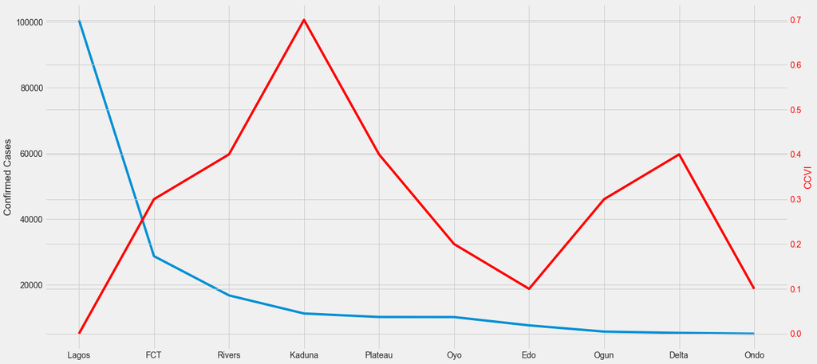

```python
fig = plt.figure(figsize=(20,10))
ax1 = fig.add_subplot()
ax1.plot(Othertop10.States, Othertop10.Confirmed)
ax1.set_ylabel('Confirmed Cases')

ax2 = ax1.twinx()
ax2.plot(Othertop10.States, Othertop10.CCVI, 'r-')
ax2.set_ylabel('CCVI', color='r')
for tl in ax2.get_yticklabels():
    tl.set_color('r')
```

#### From the Combine graph

Kadauna state has the heighest community vulnerability index despite having low cases recorded and Lagos state despites having the highest number of confirmed cases has the lowest community vulnerability index. Ondo and Edo has low community vulnerability index and low confirmed cases.

It can be infered that there is no consistent relationship between the two variables i.e confirmed cases and community vulnerability index

# TODO I

Determine the relationship between the external dataset and the NCDC COVID-19 dataset.

```python
#Generate a regression plot between two variables to visualize the linear relationships - Confirmed Cases and Population Density
```

```python
NCDC_Other.head(5)
```

|  | States Affected | No of cases lab | No of Cases | No Discharged | No of Deaths | region | Population | Overall CCVI Index | Age | Epidemiological | Fragility | Health System | Population Density | Socio-Economic | Transport Availability | Acute IHR |
| --- | --- | --- | --- | --- | --- | --- | --- | --- | --- | --- | --- | --- | --- | --- | --- | --- |
| 0 | Lagos | 100641.0 | 1,810 | 98062.0 | 769.0 | South West | 13992000.0 | 0.0 | 0.1 | 1.0 | 0.3 | 0.1 | 1.0 | 0.1 | 0.4 | 0.93 |
| 1 | FCT | 28763.0 | 63 | 28451.0 | 249.0 | North Central | 4865000.0 | 0.3 | 0.0 | 0.9 | 0.4 | 0.6 | 0.9 | 0.6 | 0.2 | 0.79 |
| 2 | Rivers | 16826.0 | 127 | 16545.0 | 154.0 | South South | 7763000.0 | 0.4 | 0.5 | 0.9 | 0.6 | 0.6 | 0.9 | 0.1 | 0.1 | 1.00 |
| 3 | Kaduna | 11314.0 | 7 | 11218.0 | 89.0 | North West | 9227000.0 | 0.7 | 0.1 | 0.9 | 0.8 | 0.9 | 0.4 | 0.6 | 0.4 | 0.86 |
| 4 | Plateau | 10258.0 | 2 | 10181.0 | 75.0 | North Central | 4766000.0 | 0.4 | 0.5 | 0.4 | 0.8 | 0.3 | 0.3 | 0.5 | 0.3 | 0.93 |

```python
NCDC_Other.rename(columns = {'No of cases lab':'Confirmed'}, inplace = True)
NCDC_Other.rename(columns = {'States Affected':'States'}, inplace = True)
```

```python
NCDC_Other.rename(columns = {'Population Density':'PoPDensity'}, inplace = True)
```

```python
#Plotting the a regression graph of Confirmed Cases (y= Confirmed) against Population density (x= PoPDensity)
```

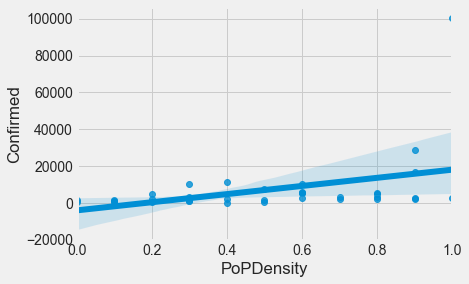

```python
ax = sns.regplot(x="PoPDensity", y="Confirmed", data=NCDC_Other)
```

# TODO J

Providing more analyses by extending TODO G & H. Meaning, determine relationships between more features.

```python
NCDC_Other.rename(columns = {'Health System':'Health_System'}, inplace = True)
```

```python
#Plotting the graphs of States showing their Health Systems and Social Economic status
```

```python
NCDC_Other.rename(columns ={'States Affected': 'States'}, inplace = True)
```

```python
NCDC_Other.rename(columns ={'Socio-Economic': 'Socio_Economic'}, inplace = True)
```

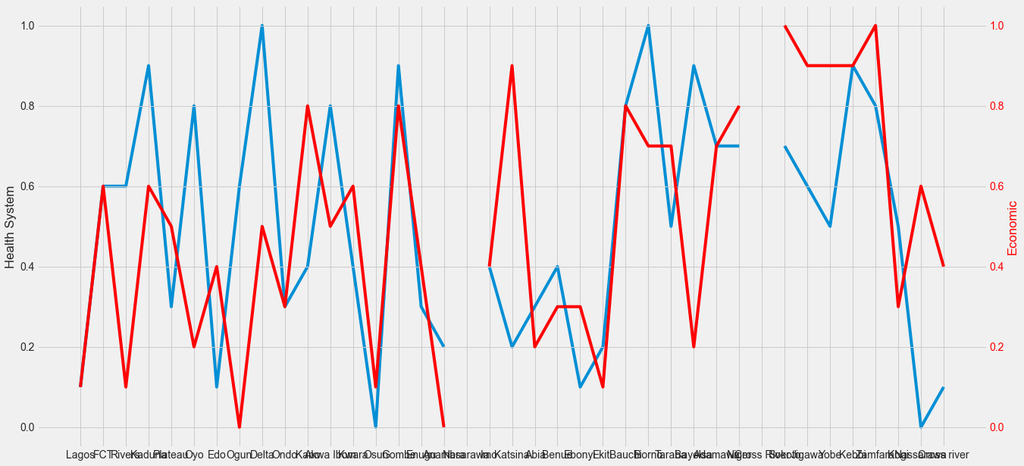

```python
fig = plt.figure(figsize=(20,10))
ax1 = fig.add_subplot()
ax1.plot(NCDC_Other.States, NCDC_Other.Health_System)
ax1.set_ylabel('Health System')

ax2 = ax1.twinx()
ax2.plot(NCDC_Other.States, NCDC_Other.Socio_Economic, 'r-')
ax2.set_ylabel('Economic', color='r')
for tl in ax2.get_yticklabels():
    tl.set_color('r')
```

```python
##Plotting the graphs of States showing their Health Systems and Social Economic status using the Top 10 state data
```

```python
Othertop10
```

|  | States | Confirmed | No of Cases | No Discharged | No of Deaths | region | Population | CCVI | Age | Epidemiological | Fragility | Health System | Population Density | Socio-Economic | Transport Availability | Acute IHR |
| --- | --- | --- | --- | --- | --- | --- | --- | --- | --- | --- | --- | --- | --- | --- | --- | --- |
| 0 | Lagos | 100641.0 | 1,810 | 98062.0 | 769.0 | South West | 13992000.0 | 0.0 | 0.1 | 1.0 | 0.3 | 0.1 | 1.0 | 0.1 | 0.4 | 0.93 |
| 1 | FCT | 28763.0 | 63 | 28451.0 | 249.0 | North Central | 4865000.0 | 0.3 | 0.0 | 0.9 | 0.4 | 0.6 | 0.9 | 0.6 | 0.2 | 0.79 |
| 2 | Rivers | 16826.0 | 127 | 16545.0 | 154.0 | South South | 7763000.0 | 0.4 | 0.5 | 0.9 | 0.6 | 0.6 | 0.9 | 0.1 | 0.1 | 1.00 |
| 3 | Kaduna | 11314.0 | 7 | 11218.0 | 89.0 | North West | 9227000.0 | 0.7 | 0.1 | 0.9 | 0.8 | 0.9 | 0.4 | 0.6 | 0.4 | 0.86 |
| 4 | Plateau | 10258.0 | 2 | 10181.0 | 75.0 | North Central | 4766000.0 | 0.4 | 0.5 | 0.4 | 0.8 | 0.3 | 0.3 | 0.5 | 0.3 | 0.93 |
| 5 | Oyo | 10232.0 | 1 | 10029.0 | 202.0 | South West | 8737000.0 | 0.2 | 0.7 | 0.8 | 0.2 | 0.8 | 0.6 | 0.2 | 0.3 | 1.06 |
| 6 | Edo | 7707.0 | 11 | 7375.0 | 321.0 | South South | 4705000.0 | 0.1 | 0.9 | 0.8 | 0.1 | 0.1 | 0.5 | 0.4 | 0.3 | 1.09 |
| 7 | Ogun | 5810.0 | 11 | 5717.0 | 82.0 | South West | 5878000.0 | 0.3 | 0.6 | 0.7 | 0.5 | 0.6 | 0.6 | 0.0 | 0.2 | 1.07 |
| 8 | Delta | 5413.0 | 132 | 5170.0 | 111.0 | South South | 6303000.0 | 0.4 | 0.6 | 0.7 | 0.2 | 1.0 | 0.6 | 0.5 | 0.4 | 1.08 |
| 9 | Ondo | 5173.0 | 315 | 4749.0 | 109.0 | South West | 5185000.0 | 0.1 | 0.8 | 0.5 | 0.1 | 0.3 | 0.6 | 0.3 | 0.3 | 1.04 |

```python
Othertop10.rename(columns = {'Health System':'Health_System'}, inplace = True)
```

```python
Othertop10.rename(columns = {'Population Density':'PoPDensity'}, inplace = True)
```

```python
Othertop10.rename(columns ={'Socio-Economic': 'Socio_Economic'}, inplace = True)
```

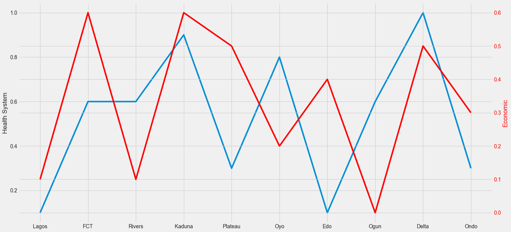

```python
fig = plt.figure(figsize=(20,10))
ax1 = fig.add_subplot()
ax1.plot(Othertop10.States, Othertop10.Health_System)
ax1.set_ylabel('Health System')

ax2 = ax1.twinx()
ax2.plot(Othertop10.States, Othertop10.Socio_Economic, 'r-')
ax2.set_ylabel('Economic', color='r')
for tl in ax2.get_yticklabels():
    tl.set_color('r')
```

#### There is no major relationship between the Socio-Economic status of a state and their Health system. For example Oyo has low socio- economic status and high health system, compare to Edo state which was reverse. Only few states like Delta, Ondo and Kaduna had a direct relationship between the two variables

```python
#Plotting a Regression graph between Epideology and Fragility using the NCDC data
```

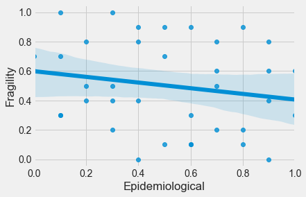

```python
ax = sns.regplot(x="Epidemiological", y="Fragility", data=NCDC_Other)
```

#### There isn't any linear relationship between the Fragility and Epidemiological status of a state. It can be infered that they are independent of one another